# hw6

Simon Lee

2022-11-21

```r
library(tidymodels)
library(tidyverse)
library(ggplot2)
library(corrr)
library(corrplot)
library(klaR)
library(glmnet)
library(MASS)
library(discrim)
library(poissonreg)
library(janitor)
library(rpart.plot)
library(vip)
library(randomForest)
library(xgboost)
library(recipes)
tidymodels_prefer()
```

# q1

```r
poke_data <- read.csv("data/pokemon.csv")
poke_data <- poke_data %>% clean_names()
fpoke_data <- poke_data %>% filter((type_1 == "Bug" | type_1 == "Fire" | type_1 == "Grass" | type_1 == "Normal" |
                           type_1 == "Water" | type_1 == "Psychic"))
fpoke_data$type_1 <- as.factor(fpoke_data$type_1)
fpoke_data$legendary <- as.factor(fpoke_data$legendary)
fpoke_data$generation <- as.factor(fpoke_data$generation)

set.seed(558)
poke_split <- initial_split(fpoke_data, prop = 0.8, strata = type_1)
poke_train <- training(poke_split)
poke_test <- testing(poke_split)

poke_fold <- vfold_cv(data = poke_train, v=5, strata = type_1)
poke_fold
```

```
## #  5-fold cross-validation using stratification
## # A tibble: 5 × 2
##   splits           id
##   <list>           <chr>
## 1 <split [289/75]> Fold1
## 2 <split [291/73]> Fold2
## 3 <split [291/73]> Fold3
## 4 <split [292/72]> Fold4
## 5 <split [293/71]> Fold5
```

```r
poke_recipe <- recipe(type_1 ~ legendary + generation + sp_atk + attack + speed + defense + hp + sp_def, data= poke_train) %>%
  step_dummy(legendary) %>%
  step_dummy(generation) %>%
  step_normalize(all_predictors())
```

# q2

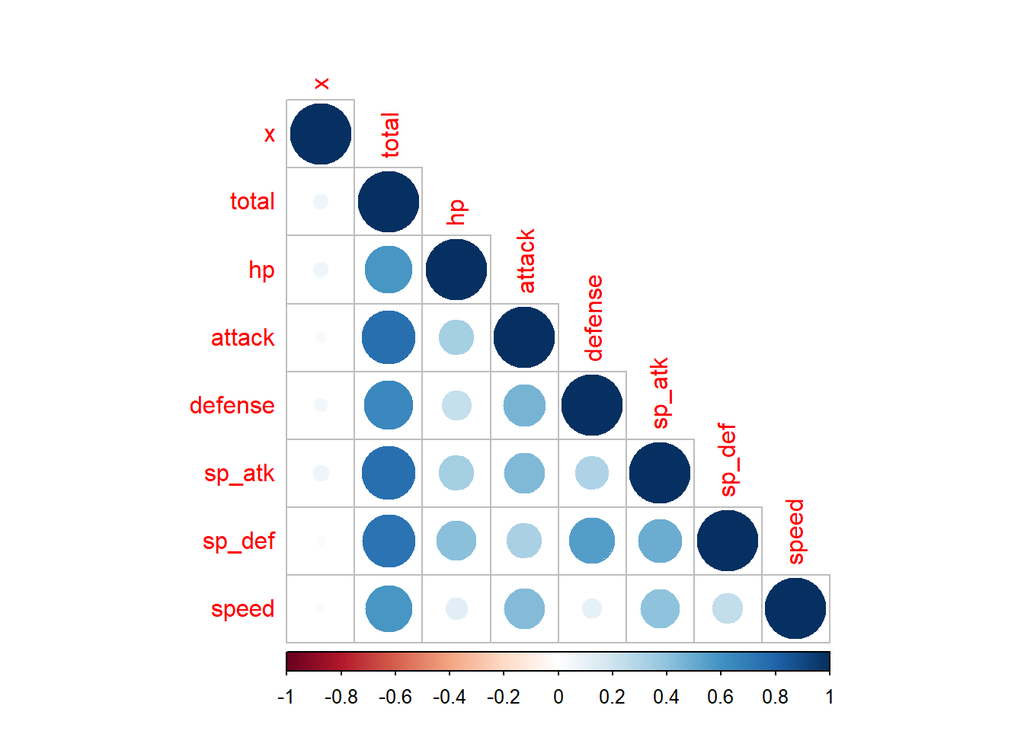

```r
fpoke_data %>% select(is.numeric) %>%
  cor() %>%
  corrplot(type = "lower")
```

Looking at the correlation plot there seems to be no negative correlation between any of the variables. There does seem to be positive correlation between speed with attack and special attack. Special defense is correlated with defense. Which makes sense as something with high defense should have high special defense and something with strong speed should be high attack since its offensive.

# q3

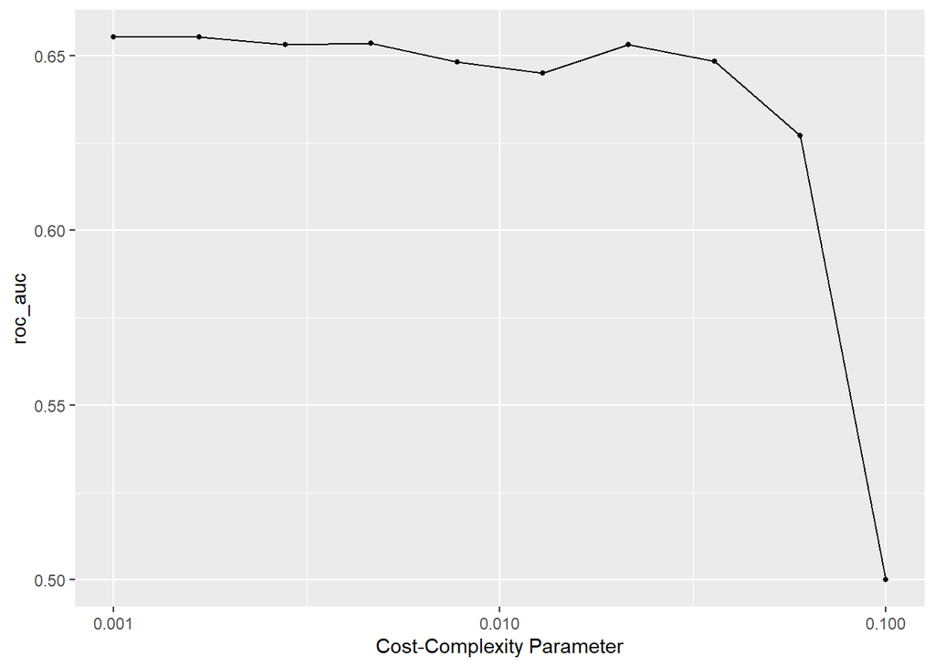

```r
autoplot(tune_res_tree)
```

# q4

```r
collect_metrics(tune_res_tree) %>%  arrange(desc(mean))
```

```
## # A tibble: 10 × 7
##    cost_complexity .metric .estimator  mean     n std_err .config
##              <dbl> <chr>   <chr>      <dbl> <int>   <dbl> <chr>
##  1         0.001   roc_auc hand_till  0.655     5  0.0107 Preprocessor1_Model01
##  2         0.00167 roc_auc hand_till  0.655     5  0.0107 Preprocessor1_Model02
##  3         0.00464 roc_auc hand_till  0.654     5  0.0101 Preprocessor1_Model04
##  4         0.0215  roc_auc hand_till  0.653     5  0.0237 Preprocessor1_Model07
##  5         0.00278 roc_auc hand_till  0.653     5  0.0110 Preprocessor1_Model03
##  6         0.0359  roc_auc hand_till  0.648     5  0.0191 Preprocessor1_Model08
##  7         0.00774 roc_auc hand_till  0.648     5  0.0118 Preprocessor1_Model05
##  8         0.0129  roc_auc hand_till  0.645     5  0.0172 Preprocessor1_Model06
##  9         0.0599  roc_auc hand_till  0.627     5  0.0159 Preprocessor1_Model09
## 10         0.1     roc_auc hand_till  0.5       5  0      Preprocessor1_Model10
```

```r
best_parameter_tree <- select_best(tune_res_tree, metric = "roc_auc")
best_parameter_tree
```

```
## # A tibble: 1 × 2
##   cost_complexity .config
##             <dbl> <chr>
## 1           0.001 Preprocessor1_Model01
```

The best performing decision tree was 0.655, and it had a cost_complexity of 0.001

# q5

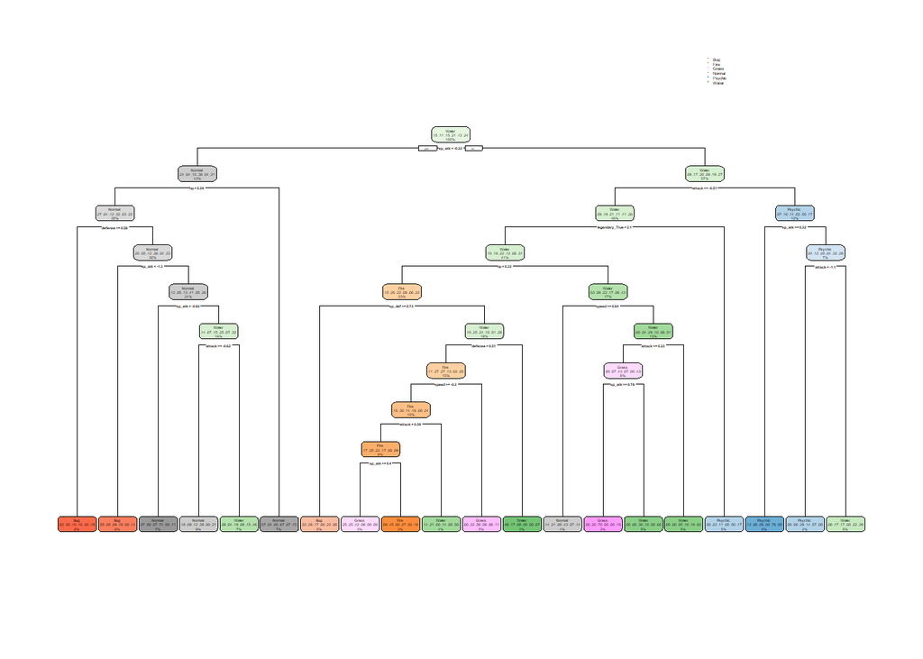

```r
poke_tree_final <- finalize_workflow(poke_tree_wf, best_parameter_tree)
poke_tree_final_fit <- fit(poke_tree_final, data = poke_train)
poke_tree_final_fit %>% extract_fit_engine() %>% rpart.plot(roundint = FALSE)
```

```r
poke_rf_spec <- rand_forest(mtry=tune(), trees=tune(), min_n=tune()) %>%
  set_engine("randomForest", importance = TRUE) %>%
  set_mode("classification")

poke_rf_wf <- workflow() %>%
  add_recipe(poke_recipe) %>%
  add_model(poke_rf_spec)
```

mtry is the number of randomly selcted variables each tree is given

trees represents the number of trees in the forest

min_n is the minimum # of data points in each node that are required for further splitting

```r
param_grid_rf <- grid_regular(mtry(range = c(1,8)),
                              trees(range = c(1,10)),
                              min_n(range = c(1,10)),
                              levels = 8)
param_grid_rf
```

```
## # A tibble: 512 × 3
##     mtry trees min_n
##    <int> <int> <int>
##  1     1     1     1
##  2     2     1     1
##  3     3     1     1
##  4     4     1     1
##  5     5     1     1
##  6     6     1     1
##  7     7     1     1
##  8     8     1     1
##  9     1     2     1
## 10     2     2     1
## # … with 502 more rows
```

# q6

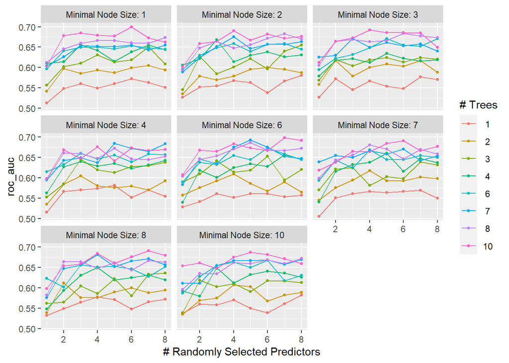

```r
autoplot(tune_res_rf)
```

Throughout all the models, it seems that the best performing models had 7, 8, or 10 trees. Generally increasing the number of randomly selected predictors seems to increase the roc_auc score.

# q7

```r
collect_metrics(tune_res_rf) %>% arrange(desc(mean))
```

```
## # A tibble: 512 × 9
##     mtry trees min_n .metric .estimator  mean     n std_err .config
##    <int> <int> <int> <chr>   <chr>      <dbl> <int>   <dbl> <chr>
##  1     6    10     1 roc_auc hand_till  0.700     5 0.0240  Preprocessor1_Model…
##  2     7    10     6 roc_auc hand_till  0.698     5 0.0151  Preprocessor1_Model…
##  3     4    10     3 roc_auc hand_till  0.692     5 0.00785 Preprocessor1_Model…
##  4     5     7     6 roc_auc hand_till  0.692     5 0.0203  Preprocessor1_Model…
##  5     8    10     6 roc_auc hand_till  0.691     5 0.0207  Preprocessor1_Model…
##  6     7    10     8 roc_auc hand_till  0.691     5 0.0172  Preprocessor1_Model…
##  7     6    10     7 roc_auc hand_till  0.691     5 0.0169  Preprocessor1_Model…
##  8     4    10     2 roc_auc hand_till  0.691     5 0.0208  Preprocessor1_Model…
##  9     5    10    10 roc_auc hand_till  0.687     5 0.0291  Preprocessor1_Model…
## 10     5     8     6 roc_auc hand_till  0.686     5 0.0140  Preprocessor1_Model…
## # … with 502 more rows
```

```r
best_parameter_rf <- select_best(tune_res_rf, metric = "roc_auc")
best_parameter_rf
```

```
## # A tibble: 1 × 4
##    mtry trees min_n .config
##   <int> <int> <int> <chr>
## 1     6    10     1 Preprocessor1_Model062
```

The best performing model was (mtry = 6, trees = 10, and min_n = 1) with a roc_auc score of 0.700

# q8

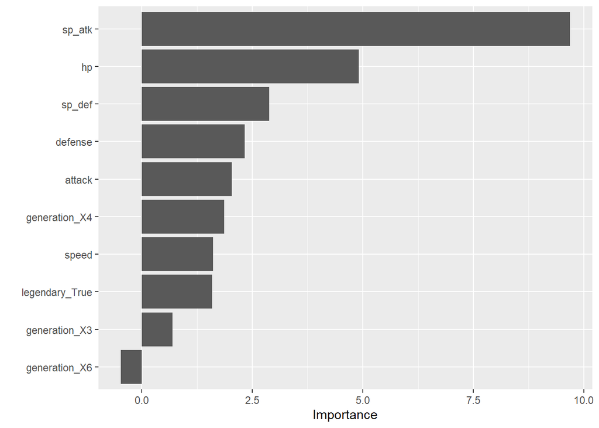

```r
poke_rf_final <- finalize_workflow(poke_rf_wf, best_parameter_rf)
poke_rf_final_fit <- fit(poke_rf_final, data = poke_train)
poke_rf_final_fit %>% extract_fit_engine() %>% vip()
```

The most important variables were special attack and hp. While the generation of the pokemon was not that useful at all. This makes sense as which generation the pokemon came out doesn’t have anything to do with its type while its hp stat could explain whether it is a strong typing or a weak typing

# q9

```r
poke_boosted_spec <- boost_tree(trees = tune()) %>%
  set_engine("xgboost") %>%
  set_mode("classification")

poke_boosted_wf <- workflow() %>%
  add_recipe(poke_recipe) %>%
  add_model(poke_boosted_spec)

param_grid_boosted <- grid_regular(trees(range = c(10, 2000)), levels = 10)

tune_res_boosted <- tune_grid(poke_boosted_wf, resamples = poke_fold, grid = param_grid_boosted, metrics = metric_set(roc_auc))
```

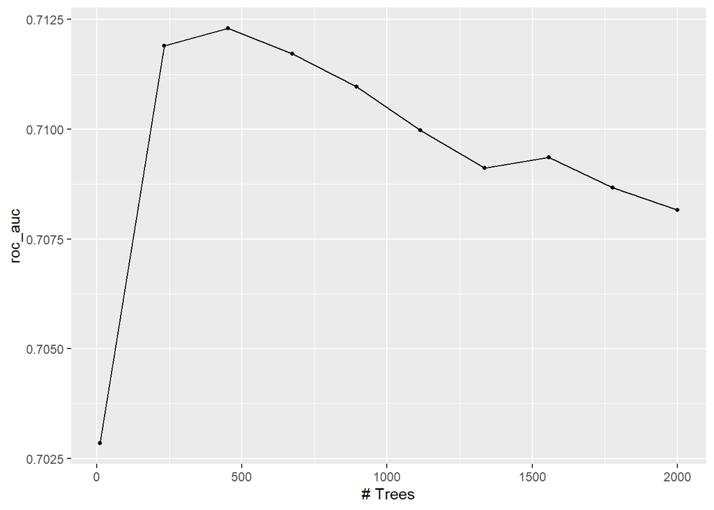

```r
autoplot(tune_res_boosted)
```

```r
collect_metrics(tune_res_boosted) %>% arrange(desc(mean))
```

```
## # A tibble: 10 × 7
##    trees .metric .estimator  mean     n std_err .config
##    <int> <chr>   <chr>      <dbl> <int>   <dbl> <chr>
##  1   452 roc_auc hand_till  0.712     5  0.0138 Preprocessor1_Model03
##  2   231 roc_auc hand_till  0.712     5  0.0143 Preprocessor1_Model02
##  3   673 roc_auc hand_till  0.712     5  0.0135 Preprocessor1_Model04
##  4   894 roc_auc hand_till  0.711     5  0.0134 Preprocessor1_Model05
##  5  1115 roc_auc hand_till  0.710     5  0.0137 Preprocessor1_Model06
##  6  1557 roc_auc hand_till  0.709     5  0.0143 Preprocessor1_Model08
##  7  1336 roc_auc hand_till  0.709     5  0.0143 Preprocessor1_Model07
##  8  1778 roc_auc hand_till  0.709     5  0.0145 Preprocessor1_Model09
##  9  2000 roc_auc hand_till  0.708     5  0.0144 Preprocessor1_Model10
## 10    10 roc_auc hand_till  0.703     5  0.0162 Preprocessor1_Model01
```

452 trees had the highest roc_auc score while the lowest score is around 10 trees.

```r
best_parameter_boosted <- select_best(tune_res_boosted, metric = "roc_auc")
best_parameter_boosted
```

```
## # A tibble: 1 × 2
##   trees .config
##   <int> <chr>
## 1   452 Preprocessor1_Model03
```

# q10

```r
tree_auc <- collect_metrics(tune_res_tree) %>% arrange(desc(mean))
forest_auc <- collect_metrics(tune_res_rf) %>% arrange(desc(mean))
boosted_auc <- collect_metrics(tune_res_boosted) %>% arrange(desc(mean))
roc_aucs <- c(tree_auc$mean[1], forest_auc$mean[1], boosted_auc$mean[1])
roc_aucs
```

```
## [1] 0.6553271 0.6995842 0.7122971
```

```r
poke_final <- finalize_workflow(poke_boosted_wf, best_parameter_boosted)
poke_final_fit <- fit(poke_final, data = poke_train)
testing_roc_auc <- augment(poke_final_fit, new_data = poke_test) %>%
  roc_auc(truth = type_1, estimate= c(.pred_Bug, .pred_Fire, .pred_Grass, .pred_Normal, .pred_Psychic, .pred_Water))
testing_roc_auc
```

```
## # A tibble: 1 × 3
##   .metric .estimator .estimate
##   <chr>   <chr>          <dbl>
## 1 roc_auc hand_till      0.685
```

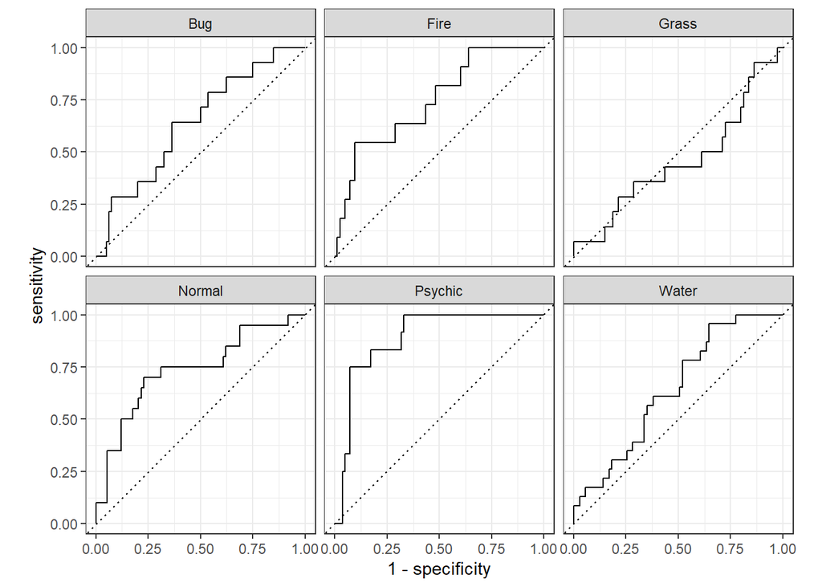

```r
roc_curves <- augment(poke_final_fit, new_data = poke_test) %>%
  roc_curve(truth = type_1, estimate = c(.pred_Bug, .pred_Fire, .pred_Grass, .pred_Normal, .pred_Psychic, .pred_Water)) %>%
  autoplot()
roc_curves
```

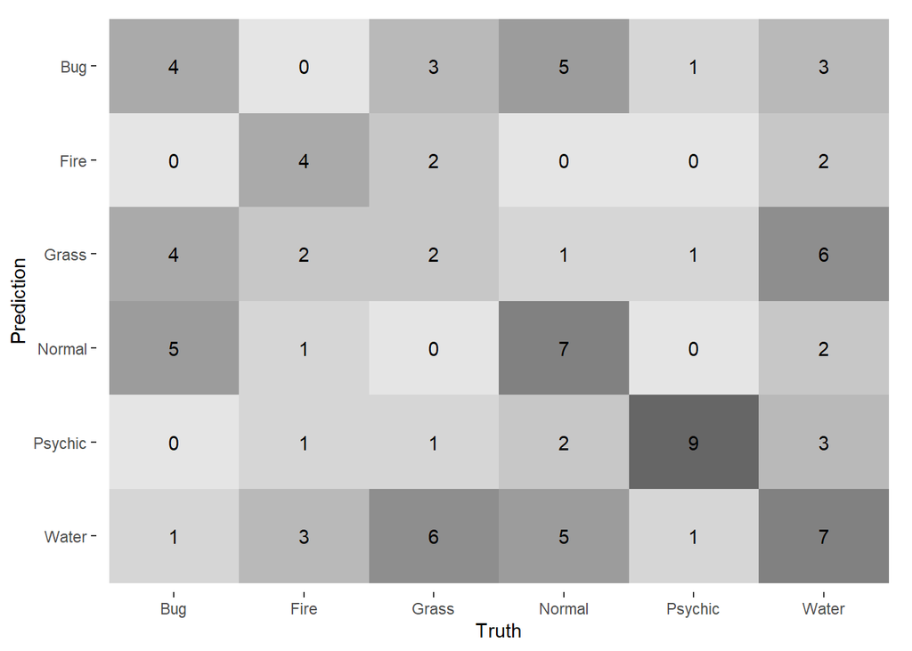

```r
final_model_conf <- augment(poke_final_fit, new_data = poke_test) %>%
  conf_mat(truth = type_1, estimate = .pred_class) %>%
  autoplot(type = "heatmap")
final_model_conf
```

The model was best at predicting psychic water and normal types. Grass was the worst as it only got 2 correct And the model was okay at predicting bug and fire type.